# Distributions and Simulation

▶️ Watch Videos: 17 minutes

- 🔗 Link to **all** Slides from Videos: [here](https://app.box.com/s/zcnbbt2xepty8ztg56ikdgdxz8oiyvws)

📖 Readings: 15-20 minutes

💻 Activities: 30 minutes

✅ Preview Activities: 1

## 1 Simulation in R

📖 [Required Reading – *R Programming for Data Science* : Simulation](https://bookdown.org/rdpeng/rprogdatascience/simulation.html)

▶️ [Required Video – Simulating Data in R (17 minutes)](https://www.youtube.com/watch?v=J5XQaxmznNE)

## 2 Preview Activity: The `r`, `p`, `q`, and `d` functions

**Question 1:** What does the output of `pnorm(-4, mean = 2, sd = 4)` mean?

**Tip**

Drawing pictures of the relevant distribution may help.

**Question 2:** Why does `rnorm(mean = 0, sd = 1)` give an error?

## 3 Setting a Random Number Seed

Functions like `rnorm()` rely on something called pseudo-randomness. Because computers can never be *truly* random, complicated processes are implemented to make “random” number generation be so unpredictable as to behave like true randomness.

This means that projects involving simulation are harder to make **reproducible**. For example, here are two identical lines of code that give different results!

```r
rnorm(1, mean = 0, sd = 1)
```

```
[1] -0.4986868
```

```r
rnorm(1, mean = 0, sd = 1)
```

```
[1] -0.7449745
```

Fortunately, pseudo-randomness depends on a **seed**, which is an arbitrary number where the randomizing process starts. Normally, R will choose the seed for you, from a pre-generated vector:

```r
head(.Random.seed)
```

```
[1]       10403           7    -7752466   160521672 -2111446325   519514921
```

However, you can also choose your own seed using the `set.seed()` function. This guarantees your results will be consistent:

```r
set.seed(1234)
rnorm(1, mean = 0, sd = 1)
```

```
[1] -1.207066
```

```r
set.seed(1234)
rnorm(1, mean = 0, sd = 1)
```

```
[1] -1.207066
```

Of course, it doesn’t mean the results will be the same in every subsequent run if you forget or reset the seed in between each line of code!

```r
set.seed(1234)
rnorm(1, mean = 0, sd = 1)
```

```
[1] -1.207066
```

```r
## Calling rnorm() again without a seed "resets" the seed!
rnorm(1, mean = 0, sd = 1)
```

```
[1] 0.2774292
```

It is very important to always set a seed at the **beginning** of an R Markdown document that contains any random steps, so that your knitted results are consistent.

Note, though, that this only guarantees your knitted results will be the same *if the code has not changed*.

Changing up any part of the code will re-randomize everything that comes after it!

## 4 Plotting Distributions

Here is the code that made one of the plots from the lecture video:

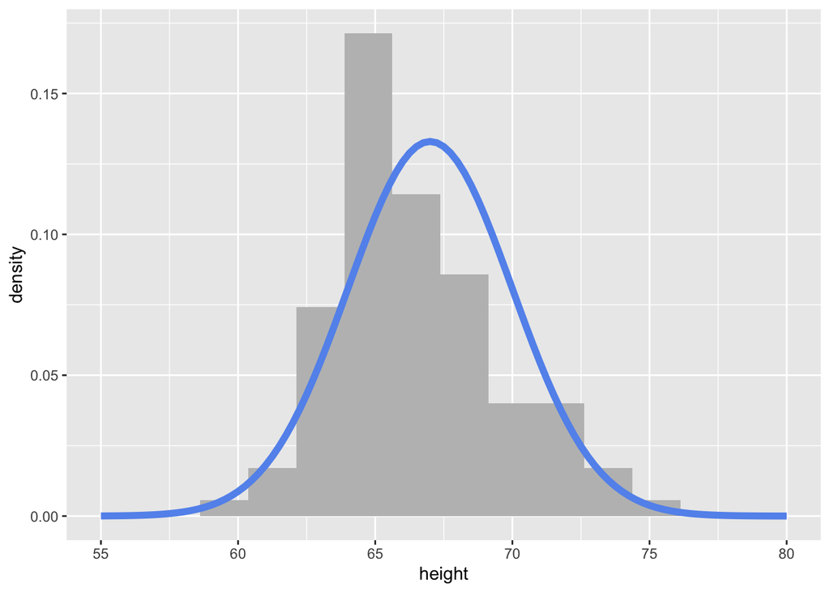

```r
my_samples <- tibble(height = rnorm(n = 100,
                                    mean = 67,
                                    sd = 3)
                     )

my_samples %>%
  ggplot(aes(x = height)) +
  geom_histogram(aes(y = ..density..),
                 binwidth = 1.75, fill = "grey") +
  stat_function(fun = ~ dnorm(., mean = 67, sd = 3),
                col = "cornflowerblue", lwd = 2) +
  xlim(c(55, 80))
```

**Adding a distribution to a plot**

Notice how I’m using `stat_function()` to add a specific function to the plot. Here, I’m using the `dnorm()` function, with a specified `mean` and `sd`.